# Coefficient of variation

Joyce Hsiao

2015-09-26

**Last updated:** 2015-09-27

**Code version:** 340bae2caf72149e06319c3bd99007fdae76b6f3

**Last updated:** 2015-09-28

**Code version:** 3f442a23f405d3564d9ab3197ec337df22fe9383

## Objectives

We used Kruskal-Wallis test to compare coefficient of variation between individual (3 coefficient of variations from the batches for per individual). The p-value distribution of the per gene Kruskal-Wallis test does not resemeble p-value distribution of the commonly know per gene tests of differential gene expression.

Visulization of the count distributions of the top 9 and bottom 9 genes that are different in coefficient of variation between individuals using the Kruskal-Wallis test did not reveal systematic different between the count distributions.

We then applied Kwame Okrah’s HTShape package to compute skewness and kurtoss estimtes of each gene with each unique batches, and also across the three individuals. The SO-plot shows that there are a good proportion of the genes that are skewed in their count distribution.

## Set up

```r
library(ggplot2)
library(edgeR)
library(limma)
```

## Prepare data

Input annotation

```r
anno <- read.table("../data/annotation.txt", header = TRUE,
                   stringsAsFactors = FALSE)
head(anno)
```

```
  individual batch well     sample_id
1      19098     1  A01 NA19098.1.A01
2      19098     1  A02 NA19098.1.A02
3      19098     1  A03 NA19098.1.A03
4      19098     1  A04 NA19098.1.A04
5      19098     1  A05 NA19098.1.A05
6      19098     1  A06 NA19098.1.A06
```

Input molecule counts

```r
molecules <- read.table("../data/molecules.txt", header = TRUE, stringsAsFactors = FALSE)
```

Remove bulk samples

```r
single_samples <- anno$well != "bulk"
anno_single <- anno[ which(single_samples), ]
molecules_single <- molecules[ , which(single_samples)]
stopifnot(ncol(molecules_single) == nrow(anno_single),
          colnames(molecules_single) == anno_single$sample_id)
```

Remove ERCC genes.

```r
nonERCC <- grep("ERCC", rownames(molecules_single), invert = TRUE)
molecules_single <- molecules_single[nonERCC, ]
```

Remove genes with no counts and also overly expressed genes.

```r
## remove gene with 0 counts
expressed_single <- rowSums(molecules_single) > 0
molecules_single <- molecules_single[expressed_single, ]
dim(molecules_single)
```

```
[1] 17687   864
```

```r
## remove gene with molecule count larger than 1024 (15 if them)
overexpressed_genes <- rownames(molecules_single)[apply(molecules_single, 1,
                                                        function(x) any(x >= 1024))]
molecules_single <- molecules_single[!(rownames(molecules_single) %in% overexpressed_genes), ]

## collision probability and cpm molecule counts
molecules_single_collision <- -1024 * log(1 - molecules_single / 1024)
molecules_single_cpm <- cpm(molecules_single_collision, log = TRUE)
```

## Compute coefficient of variation

Per individual coefficient of variation.

```r
molecules_cv <-
  lapply(1:length(unique(anno_single$individual)), function(per_person) {
    molecules_per_person <- molecules_single_collision[ , anno_single$individual == unique(anno_single$individual)]
    cv_foo <- data.frame(mean = apply(molecules_per_person, 1, mean, na.rm = TRUE),
           cv = apply(molecules_per_person, 1, sd, na.rm = TRUE) /
                apply(molecules_per_person, 1, mean, na.rm = TRUE) )
    rownames(cv_foo) <- rownames(molecules_single_collision)

    cv_foo <- cv_foo[rowSums(is.na(cv_foo)) == 0, ]
    cv_foo$individual <- unique(anno_single$individual)[per_person]

    return(cv_foo)
    })
names(molecules_cv) <- unique(anno_single$individual)
```

Per batch coefficient of variation.

```r
unique_batch <- with(anno_single, paste(individual, batch, sep = "_"))

molecules_cv_batch <-
  lapply(1:length(unique(unique_batch)), function(per_batch) {
    molecules_per_batch <- molecules_single_collision[ , unique_batch == unique(unique_batch)[per_batch]]
    cv_foo <- data.frame(mean = apply(molecules_per_batch, 1, mean, na.rm = TRUE),
           cv = apply(molecules_per_batch, 1, sd, na.rm = TRUE) /
                apply(molecules_per_batch, 1, mean, na.rm = TRUE) )
    rownames(cv_foo) <- rownames(molecules_single_collision)

    cv_foo <- cv_foo[rowSums(is.na(cv_foo)) == 0, ]
    cv_foo$batch <- unique(unique_batch)[per_batch]

    return(cv_foo)
    })
names(molecules_cv_batch) <- unique(unique_batch)
```

Subset CV data to include only genes that have data across all batches.

```r
all_genes <- lapply(1:3, function(ii) {
                intersect(intersect(rownames(molecules_cv_batch[[ 1+ (ii-1)*3]]),
                                    rownames(molecules_cv_batch[[ 2+ (ii-1)*3]]) ),
                          rownames(molecules_cv_batch[[3 + (ii-1)*3]]) ) })
all_genes <- intersect(intersect(all_genes[[1]], all_genes[[2]]), all_genes[[3]])
str(all_genes)
```

```
 chr [1:13115] "ENSG00000237683" "ENSG00000188976" ...
```

```r
molecules_cv_batch <-
  lapply(1: length(molecules_cv_batch), function(per_batch) {
          ii_include <- which(rownames(molecules_cv_batch[[per_batch]]) %in% all_genes)
          molecules_cv_batch[[per_batch]][ ii_include, ]
  })

stopifnot(all.equal(rownames(molecules_cv_batch[[9]]), rownames(molecules_cv_batch[[8]]) ) )

nrow(molecules_cv_batch[[1]])
```

```
[1] 13115
```

## Kruskal-Wallis test

A nonparametric test commonly used for comparison of multiple groups that have a very small sample size.

```r
df_cv <- lapply(1:nrow(molecules_cv_batch[[1]]), function(per_gene) {
  do.call(rbind, lapply(1: length(molecules_cv_batch), function(per_batch) {
                    molecules_cv_batch[[per_batch]][per_gene, ] })
                  )
})

# Create a factor variable of individual
individual <- rep(unique(anno_single$individual), times = 3)

# Kruskal walls
kw_pval <- lapply(1:nrow(molecules_cv_batch[[1]]), function(per_gene) {
  result <- kruskal.test(cv ~ factor(individual), data = df_cv[[per_gene]])
  data.frame(pval = result$p.value,
             gene = rownames(molecules_cv_batch[[1]])[per_gene])
})
kw_pval <- do.call(rbind, kw_pval)


summary(kw_pval$pval)
```

```
   Min. 1st Qu.  Median    Mean 3rd Qu.    Max.
0.02651 0.28810 0.56110 0.51490 0.73260 1.00000
```

```r
ggplot(data = kw_pval, aes(x = pval)) + geom_histogram() +
  ggtitle("Kruskal-Wallis p-value")
```

```
stat_bin: binwidth defaulted to range/30. Use 'binwidth = x' to adjust this.
```

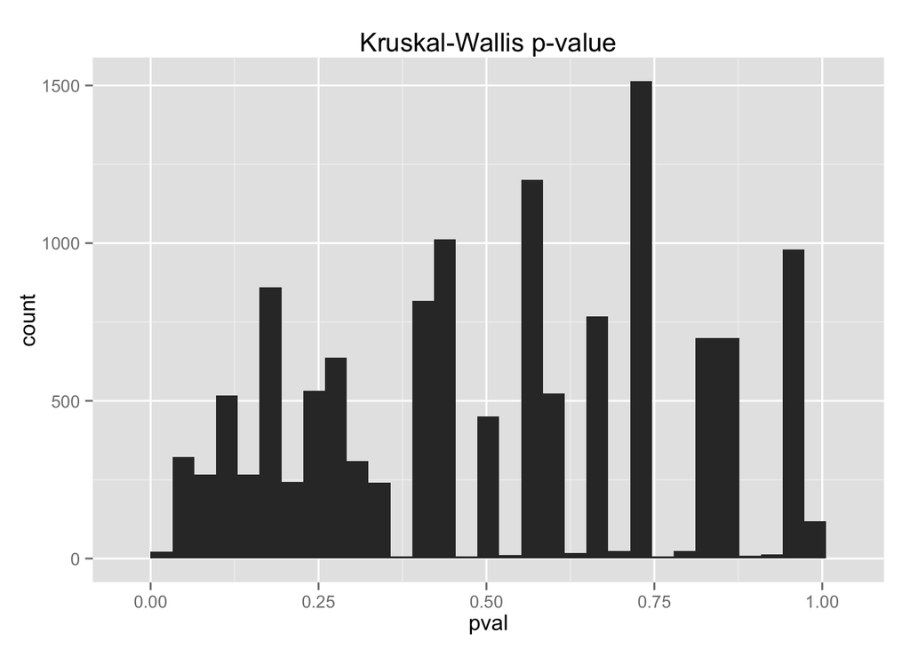

[output not shown]

[figure not shown]

```r
# library(ggplot2)
# ggplot(data = molecules_cv[[1]], aes(x = mean, y = cv)) +
#   geom_point(size = 2, alpha = .5) + scale_x_log10() +
#   geom_point(data = data.frame(mean = molecules_cv[[1]]$mean,
#                                cv_adj = cv_adj), aes(x = mean, y = cv_adj),
#              size = 2, alpha = .5, col = "blue")
```

## Top 9 in Kruskal-Wallis

```r
ii_diff <- order(kw_pval$pval)[1:9]
gene_subset <- df_cv[ii_diff]

df_cv_merge <- lapply(1:9, function(per_gene) {
          data.frame(gene_subset[[per_gene]],
                     individual = rep(c("19098", "19101", "19239"), 3),
                     gene = kw_pval$gene[ii_diff[per_gene]])
})
df_cv_merge <- do.call(rbind, df_cv_merge)

ggplot(df_cv_merge, aes( x = factor(individual), y = cv)) +
  geom_point(aes(col = factor(individual))) + facet_grid(. ~ gene)
```

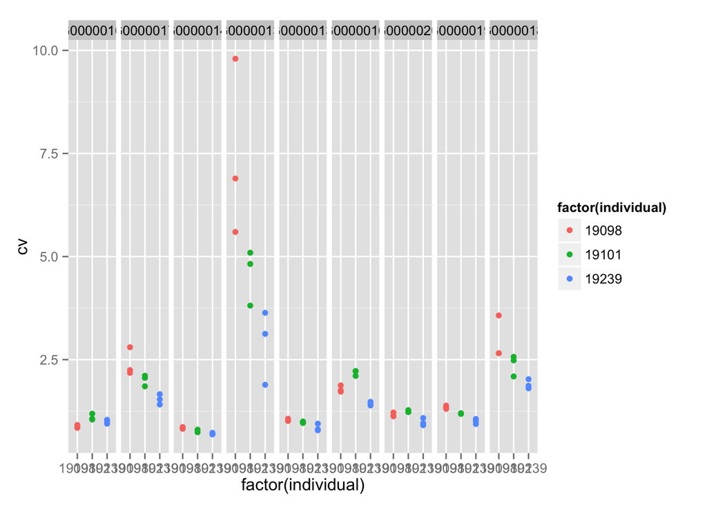

[figure not shown]

```r
unique_batch <- with(anno_single, paste(individual, batch, sep = "_"))
count_cell <- lapply(1:9, function(per_batch) {
    ii_batch <- which(unique_batch %in% unique(unique_batch)[per_batch])
    ii_gene <- which( rownames(molecules_single_collision) %in% kw_pval$gene[ii_diff] )
    df_foo <- molecules_single_collision[ii_gene, ii_batch]
    colnames(df_foo) <- ""

    df_meta <- data.frame(df_foo,
                         individual = anno_single$individual[ii_batch][1],
                         batch = anno_single$batch[ii_batch][1],
                         genes = rownames(df_foo))
    df_meta
})
names(count_cell) <- unique(unique_batch)

count_cell_merge <- do.call(rbind, count_cell)

table(count_cell_merge$individual)
```

```
19098 19101 19239
   27    27    27
```

```r
count_cell_merge <- reshape(count_cell_merge, direction = "long",
                            timevar = "gene", varying = list(1:96) )

ggplot(count_cell_merge,
        aes( x = Var.1, group = factor(paste(individual, batch, "_"))) ) +
        geom_density(aes(x = Var.1, col = factor(individual)) ) +
        facet_wrap( ~ genes, scales = "free")
```

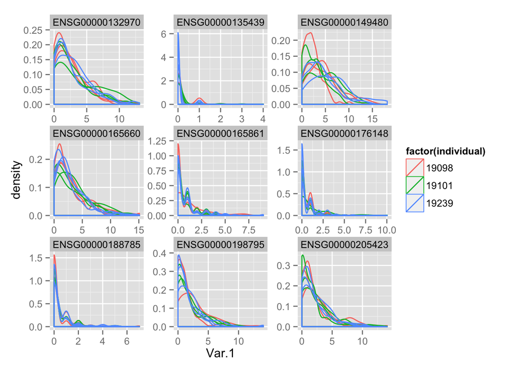

[figure not shown]

## Bottom 9 in Kruskal-Wallis

```r
ii_diff <- order(kw_pval$pval, decreasing = TRUE)[1:9]
gene_subset <- df_cv[ii_diff]

df_cv_merge <- lapply(1:9, function(per_gene) {
          data.frame(gene_subset[[per_gene]],
                     individual = rep(c("19098", "19101", "19239"), 3),
                     gene = kw_pval$gene[ii_diff[per_gene]])
})
df_cv_merge <- do.call(rbind, df_cv_merge)

ggplot(df_cv_merge, aes( x = factor(individual), y = cv)) +
  geom_point(aes(col = factor(individual))) + facet_grid(. ~ gene)
```

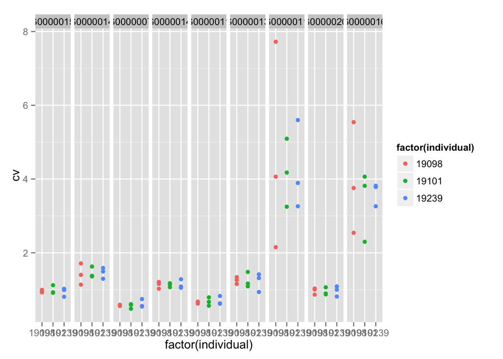

[figure not shown]

```r
unique_batch <- with(anno_single, paste(individual, batch, sep = "_"))
count_cell <- lapply(1:9, function(per_batch) {
    ii_batch <- which(unique_batch %in% unique(unique_batch)[per_batch])
    ii_gene <- which( rownames(molecules_single_collision) %in% kw_pval$gene[ii_diff] )
    df_foo <- molecules_single_collision[ii_gene, ii_batch]
    colnames(df_foo) <- ""

    df_meta <- data.frame(df_foo,
                         individual = anno_single$individual[ii_batch][1],
                         batch = anno_single$batch[ii_batch][1],
                         genes = rownames(df_foo))
    df_meta
})
names(count_cell) <- unique(unique_batch)

count_cell_merge <- do.call(rbind, count_cell)

count_cell_merge <- reshape(count_cell_merge, direction = "long",
                            timevar = "gene", varying = list(1:96) )

ggplot(count_cell_merge,
        aes( x = Var.1, group = factor(paste(individual, batch, "_"))) ) +
        geom_density(aes(x = Var.1, col = factor(individual)) ) +
        facet_wrap( ~ genes, scales = "free")
```

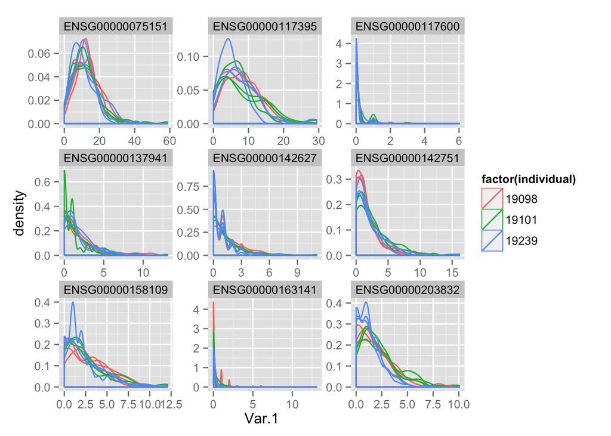

[figure not shown]

## Explore quantiles

Use Kwame’s package to compare shapes of distributions.

```r
require(devtools)
install_github("kokrah/HTshape")
```

[output not shown]

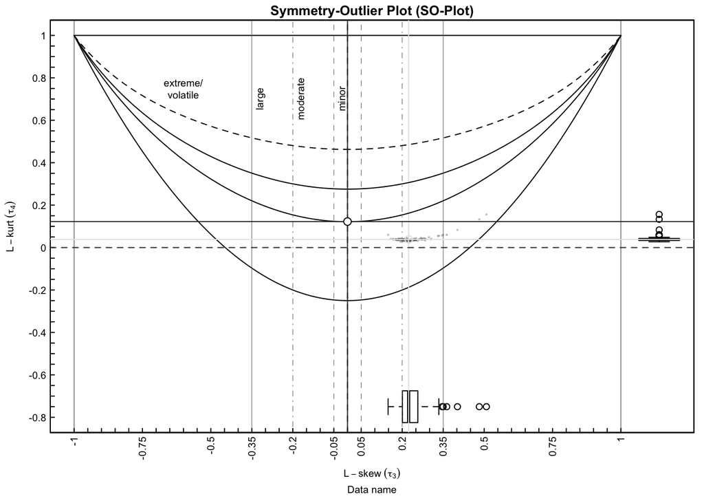

[figure not shown]

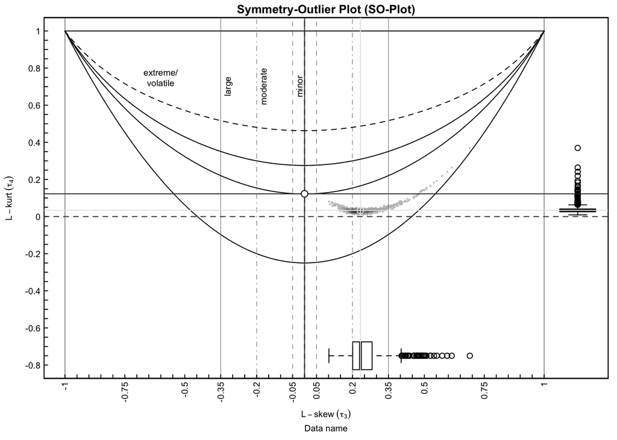

[figure not shown]